# R Notebook

```r
library(tidyverse)
library(CodeClanData)
library(wesanderson)
library(viridis)
```

qb_revenue_breakdown qb_monthly_sales qb_competitors qb_device_data

4 MVP

4.1 Part 1 1. Take the data in the dataset qb_revenue_breakdown and make a stacked bar chart showing the sources of revenue across the two years in the dataset.

```r
qb_revenue_breakdown
```

[output not shown]

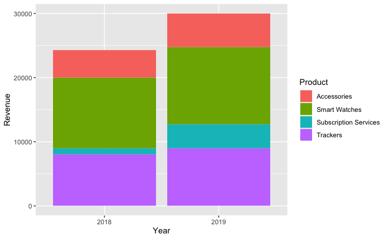

```r
ggplot(qb_revenue_breakdown) +
  aes(x = Year, y = Revenue, fill = Product) +
  geom_col()
```

2. Make a line chart showing monthly sales of the “flagship product” - the KwikBit Unit1 - over the last year. This data is inside qb_monthly_sales, but you will need to use subset.

```r
qb_monthly_sales
```

[output not shown]

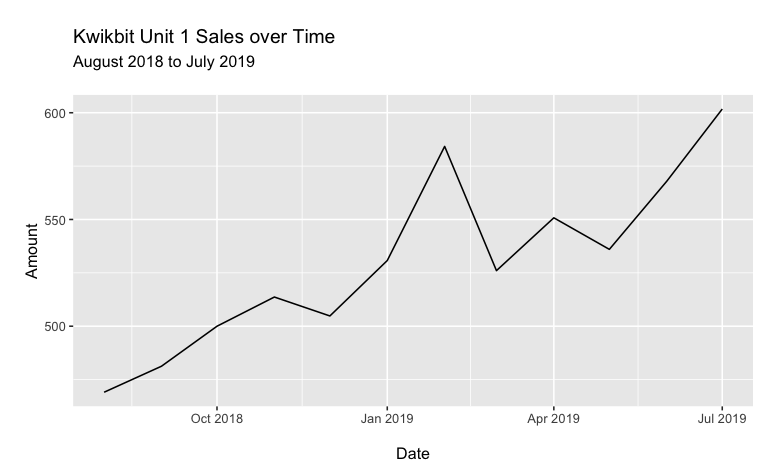

```r
ggplot(qb_monthly_sales) +
  aes(x = Date, y = Amount) +
  geom_line(data = subset(qb_monthly_sales, Cashflow == "Kwikbit Unit 1 Sales")) +
  labs(
    title = "\nKwikbit Unit 1 Sales over Time",
    subtitle = "August 2018 to July 2019\n",
    x = "\nDate",
    y = "\nAmount"
  )
```

3. Make a line chart showing monthly revenue and costs over the last year. This data is also in qb_monthly_sales.

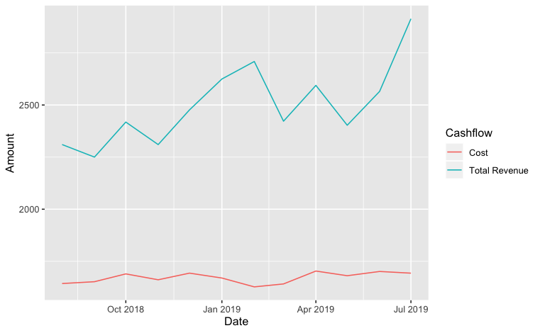

```r
ggplot(qb_monthly_sales) +
  aes(x = Date, y = Amount, colour = Cashflow) +
  geom_line(data = subset(qb_monthly_sales, Cashflow != "Kwikbit Unit 1 Sales"))
```

4. Show annual sales of personal fitness trackers over the last 5 years broken down by company as a ribbon plot (use geom_area). This data is in qb_competitors.

```r
qb_competitors
```

[output not shown]

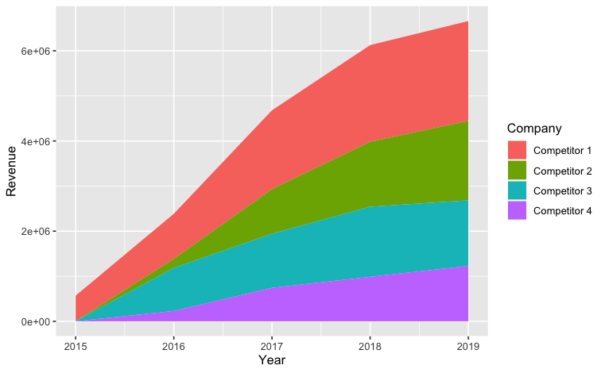

```r
ggplot(qb_competitors) +
  aes(x = Year, y = Revenue, fill = Company) +
  geom_area()
```

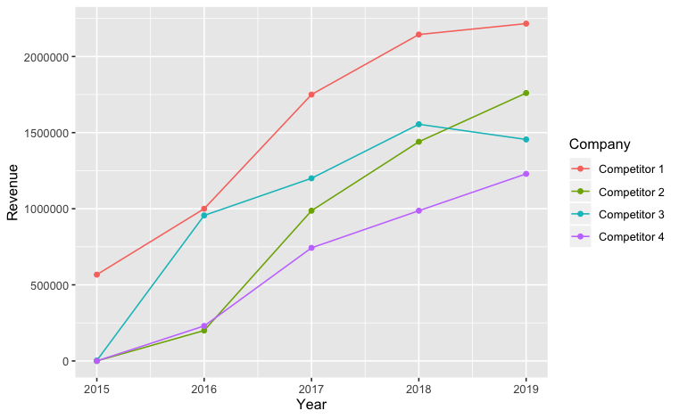

```r
ggplot(qb_competitors) +
  geom_line(aes(x = Year, y = Revenue, colour = Company)) +
  geom_point(aes(x = Year, y = Revenue, colour = Company))
```

6. Now the company wants to compare the number of steps that their device counts vs. their competitors. Make a line graph of the number of steps throughout time, and use faceting to compare between individuals and devices. Data is in qb_device_data.

```r
qb_device_data
```

[output not shown]

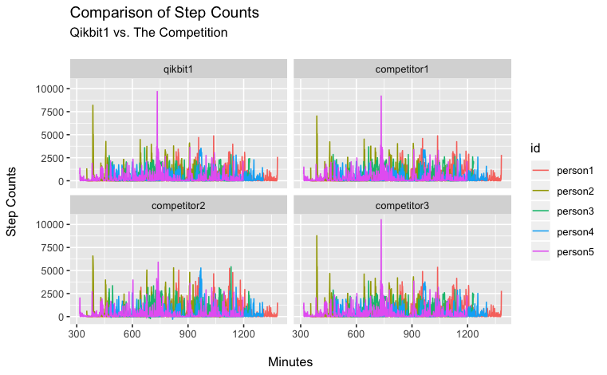

```r
device_plot <- qb_device_data %>%
  mutate(total_minutes = hours * 60 + mins) %>%
  ggplot +
  aes(x = total_minutes, y = counts, colour = id) +
  geom_line() +
  facet_wrap(~ device) +
  labs(
    x = "\nMinutes",
    y = "Step Counts\n",
    title = "Comparison of Step Counts",
    subtitle = "Qikbit1 vs. The Competition\n"
  )
device_plot
```

4.2 Part 2 Take the plots that you produced in part one and now polish them by:

1. Adding appropriate labels
2. Changing the scales and coordinates when appropriate.
3. Applying a unified theme, which is described below:
- Graphs should have white backgrounds, and use colour sparingly.
- There should be faint grid lines.
- Font sizes should be ~12pt although titles should be slightly larger and axis labels can be slightly smaller.
- All plots should use colours from the following company colour scheme.

```r
col_scheme <- c("#E89FE9", "#50434F", "#B6A7B5", "#F9A472", "#BD7040")
```

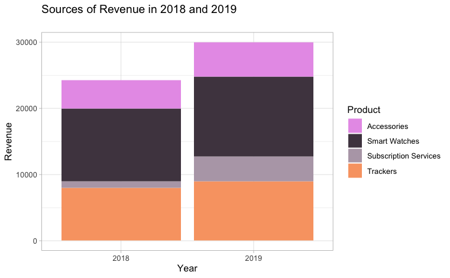

```r
ggplot(qb_revenue_breakdown) +
  aes(x = Year, y = Revenue, fill = Product) +
  geom_col() +
  scale_fill_manual(values = col_scheme) +
  labs(
    title = "Sources of Revenue in 2018 and 2019\n"
  ) +
  theme_light()
```

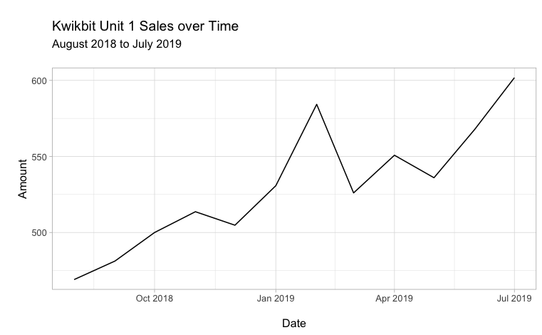

```r
ggplot(qb_monthly_sales) +
  aes(x = Date, y = Amount) +
  geom_line(data = subset(qb_monthly_sales, Cashflow == "Kwikbit Unit 1 Sales")) +
  labs(
    title = "\nKwikbit Unit 1 Sales over Time",
    subtitle = "August 2018 to July 2019\n",
    x = "\nDate",
    y = "\nAmount"
  ) +
  theme_light()
```

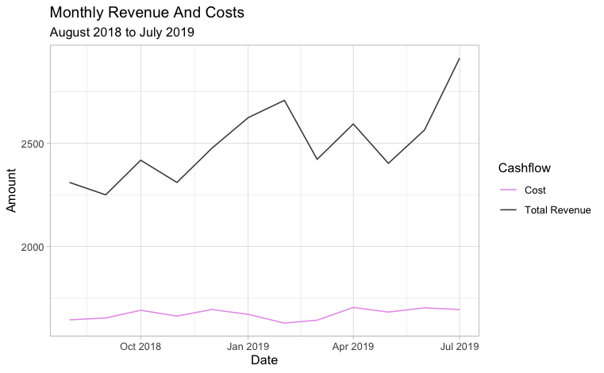

```r
ggplot(qb_monthly_sales) +
  aes(x = Date, y = Amount, colour = Cashflow) +
  geom_line(data = subset(qb_monthly_sales, Cashflow != "Kwikbit Unit 1 Sales")) +
  scale_colour_manual(values = col_scheme) +
  labs(
    title = "Monthly Revenue And Costs",
    subtitle = "August 2018 to July 2019"
  ) +
  theme_light()
```

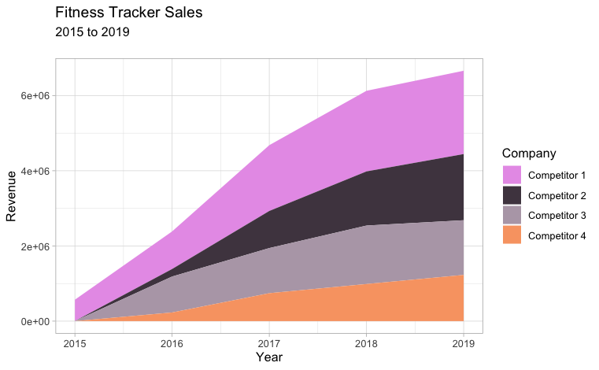

```r
ggplot(qb_competitors) +
  aes(x = Year, y = Revenue, fill = Company) +
  geom_area() +
  labs(
    title = "Fitness Tracker Sales",
    subtitle = "2015 to 2019\n"
  ) +
  scale_fill_manual(values = col_scheme) +
  theme_light()
```

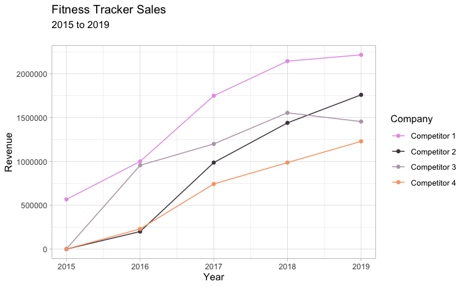

```r
ggplot(qb_competitors) +
  geom_line(aes(x = Year, y = Revenue, colour = Company)) +
  geom_point(aes(x = Year, y = Revenue, colour = Company)) +
  labs(
    title = "Fitness Tracker Sales",
    subtitle = "2015 to 2019\n"
  ) +
  scale_colour_manual(values = col_scheme) +
  theme_light()
```

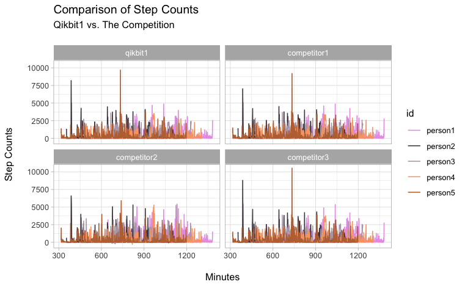

```r
device_plot <- qb_device_data %>%
  mutate(total_minutes = hours * 60 + mins) %>%
  ggplot +
  aes(x = total_minutes, y = counts, colour = id) +
  geom_line() +
  facet_wrap(~ device) +
  labs(
    x = "\nMinutes",
    y = "Step Counts\n",
    title = "Comparison of Step Counts",
    subtitle = "Qikbit1 vs. The Competition\n"
  ) +
  scale_colour_manual(values = col_scheme) +
  theme_light()
device_plot
```